# **Fourier Transform**

A fourier transform decomposes a complex valued function into its component frequencies and amplitudes. Often this is thought of as relating a function's time domain to its frequancy domain - when a time is input, the related frequency is output. Put simply, a fourier transform is a way of splitting a function into sine waves

## Fourier Series

A Fourier series is a type of trigonometric series. It is an expansion of a periodic function (a function that repeats at regular intervals) into a sum of trigonometric functions. A function is said to be periodic with period T, if $f(x+T) = f(x)$, for all $x$.

It first came about when the french mathematician Joseph Fourier was analysing the heat flow in a metal rod. While solving the heat equation, he came up with the idea of representing the heat source through an infinite series of sine and cosine functions. This technique can be applied to wide selection of problems.

The Fourier series of a $2L$ periodic function $f(x)$ is given by $$f(x) = \frac{a_0}{2}+\displaystyle\sum_{k=1} ^{\infty} (a_k \cos(\frac{k\pi x}{L})+b_k \sin(\frac{k\pi x}{L}))$$ Where:

- $a$ and $b$ are the Fourier coefficients, which are the amplitudes of the sinusoidal funtions that make up the series
- $k$ is the current sample being considered (expand on sample (time or wave))
- $\frac{\pi}{L}$ represents the fundamental frequency (the lowest frequency) of the periodic function

This is the sine-cosine form of the series, however there are others, most notably the exponential form, as it allows complex valued functions to be represented. $$f(x) = \displaystyle\sum_{k=1} ^{\infty} (C_k e^{i\pi \frac{k}{L} x})$$ This version of the theorem uses Euler's formula to compactly represent a circle.

[figure not shown]

## Fourier Coefficients

The fourier coefficients $a_0, a_k$ and $b_k, k=1,2,3,\cdots ,$ are given by the equations

$$a_0 = \frac{1}{L} \int_{-L}^{L}f(x)\,dx$$ $$a_k = \frac{1}{L} \int_{-L}^{L}f(x)\cos(\frac{k\pi x}{L})\,dx$$ $$b_k = \frac{1}{L} \int_{-L}^{L}f(x)\sin(\frac{k\pi x}{L})\,dx$$ To derive the formulas for the coefficients, the orthogonality conditions are used:

1. The average value of $\cos(nx)$ and $\sin(nx)$ over a period is zero. $$ \int_{-\pi}^{\pi} \cos(nx)\,dx = 0$$ $$ \int_{-\pi}^{\pi} \sin(nx)\,dx = 0$$
2. The average value of $\sin(mx)\cos(nx)$ over a period is zero. $$ \int_{-\pi}^{\pi} \sin(mx)\cos(nx)\,dx = 0$$
3. The average value of $\sin(mx)\sin(nx)$ over a period is $\pi$ if $m = n\neq 0$ or $0$ otherwise. $$ \int_{-\pi}^{\pi} \sin(mx)\sin(nx)\,dx = \begin{cases} \pi & \text{if $m = n \neq 0$} \\ 0 & \text{otherwise} \end{cases}$$
4. The average value of $\cos(mx)\cos(nx)$ over a period is $2\pi$ if $m = n = 0$, $\pi$ if $m = n \neq 0$, $0$ if $m\neq n$ $$ \int_{-\pi}^{\pi} \cos(mx)\cos(nx)\,dx = \begin{cases} 2\pi & \text{if $m = n = 0$} \\ \pi & \text{if $m = n \neq 0$} \\ 0 & \text{otherwise} \end{cases}$$ These orthogonality conditions can be proved using the double angle formulea.

### Finding $a_k$

First we assume that the function can be represented by $$\begin{equation*} \begin{aligned}f(x)&=\frac{1}{2} a_0 + a_1\cos x + a_2\cos 2x + a_3\cos 3x + \cdots \\ &+ b_1 \sin x + b_2 \sin 2x + b_3 \sin 3x + \cdots \end{aligned} \end{equation*}$$ Then we multiply $f(x)$ by $\cos(kx)$, $k \geq 1$, and integrate from $-\pi$ to $\pi$. Looking at the orthogonality conditions, it can be seen that the integral will be equal to $a_k\pi$. $$\begin{equation*} \begin{aligned} \int_{-\pi}^{\pi} f(x)\cos(kx)\,dx &= \frac{1}{2} a_0 \int_{-\pi}^{\pi}\cos(kx)\,dx + a_1\int_{-\pi}^{\pi}\cos(kx)\cos x\,dx + a_2\int_{-\pi}^{\pi}\cos(kx)\cos2x\,dx + a_3\int_{-\pi}^{\pi}\cos(kx)\cos3x\,dx + \cdots \\ &+ b_1\int_{-\pi}^{\pi}\cos(kx)\sin x\,dx + b_2\int_{-\pi}^{\pi}\cos(kx)\sin 2x\,dx + b_3\int_{-\pi}^{\pi}\cos(kx)\sin 3x\,dx + \cdots \\ &=a_k\pi \\ \text{Therefore} \\ a_k &= \frac{1}{\pi} \int_{-\pi}^{\pi} f(x)\cos(kx)\,dx\end{aligned} \end{equation*}$$

Using the same method, $b_k$ can be found by multiplying by $\sin(kx)$, $k \geq 1$ and integrating between $-\pi$ and $\pi$. The fundamental frequency $a_0$ can be found by simply integrating f(x) between $-\pi$ and $\pi$. $\\$ This proof shows how to find the fourier coefficients for functions that are periodic over $2\pi$, however, above we showed the more general version for a function that is periodic over 2L.

## Using Fourier Series to represent a square wave

For simplicity, lets define the square wave $f(x)$ as having maximum amplitudes between $0$ and $\pi$ and minimum amplitude between $-\pi$ and $0$, and is periodic over $2\pi$. $$f(x) = \begin{cases} -1 & \text{if $-\pi \leq x < 0$} \\ 1 & \text{if $0 \leq x < \pi$} \end{cases} \text{ and } f(x+2\pi) = f(x)$$

Using the formulas for the Fourier coefficients $$\begin{equation*} \begin{aligned} a_0 &= \frac{1}{\pi} \int_{-\pi}^{\pi}f(x)\,dx \\ &= \frac{1}{\pi}(\int_{-\pi}^{0}-1\,dx + \int_{0}^{\pi}1\, dx)\ \\ &= \frac{1}{\pi}(0) \\ &= 0 \\ a_k & = \frac{1}{\pi} \int_{-\pi}^{\pi}f(x)\cos(kx)\,dx \\ &= \frac{1}{\pi}( \int_{-\pi}^{0}-\cos(kx) + \int_{0}^{\pi}\cos(kx))\,dx \\ &= \frac{1}{\pi}(\left[-\frac{\sin(kx)}{k}\right]_{-\pi}^0 + \left[\frac{\sin(kx)}{k}\right]_0^{\pi}) \\ &= \frac{1}{k\pi}(\sin(-k\pi) + \sin(k\pi)) \\ &= 0 \\ b_k &= \frac{1}{\pi} \int_{-\pi}^{\pi}f(x)\sin(kx)\,dx \\ &= \frac{1}{\pi}( \int_{-\pi}^{0}-\sin(kx) + \int_{0}^{\pi}\sin(kx))\,dx \\ &= \frac{1}{\pi}(\left[\frac{\cos(kx)}{k}\right]_{-\pi}^0 + \left[\frac{-\cos(kx)}{k}\right]_0^{\pi})\\ &= \frac{1}{k\pi}(\cos(0)-\cos(-k\pi)-\cos(k\pi)+\cos(0)) \\ &= \frac{2-2\cos(k\pi)}{k\pi} \\ &= \begin{cases} \frac{2-2}{k\pi}, \text{ if $k$ is even} \\ \frac{2+2}{k\pi}, \text{ if $k$ is odd} \end{cases} \\ &= \begin{cases} 0, \text{ if $k$ is even} \\ \frac{4}{k\pi}, \text{ if $k$ is odd} \end{cases} \end{aligned}\end{equation*}$$

The Fourier Series of f is therefore $$\begin{equation*}\begin{aligned}f(x) &=\frac{1}{2} a_0 + a_1\cos x + a_2\cos 2x + a_3\cos 3x + \cdots \\ &+ b_1 \sin x + b_2 \sin 2x + b_3 \sin 3x + \cdots \\ &= 0+0+0+0+\cdots \\ &+ \frac{4}{\pi}\sin x + 0\sin 2x + \frac{4}{3\pi}\sin 3x + 0\sin 4x + \cdots \\ &= \frac{4}{\pi}\sin x + \frac{4}{3\pi}\sin 3x + \frac{4}{5\pi}\sin 5x + \frac{4}{7\pi}\sin 7x + \cdots \end{aligned}\end{equation*}$$

This graph shows the square wave and its fourier series up to $k = 7$. As $k$ tends to infinity, the fourier series will get closer to the square wave.

[figure not shown]

## Cool applications

### Compression

Once a fourier transform is used on a wave, instad of storig the complictated wave, just the most important frequencies are saved as the first few sines and cosines added to the series have the greatest effect on the shape of the wave. This is often applied to sound files.

### JPEG

This file type is used to store image data, and is popular because of its efficient file size.

[figure not shown]

JPEGs split the image into groups of 8x8 pixels, and use a Discrete Cosine Transformation, which is very similar to a fourier transform, to represent the image. The basis cosine functions (visualised below), are the optimal cosine inputs to use. These are layered onto eachother with varying intensity to create the image.

[figure not shown]

```
array([[0.7372549 , 0.74509804, 0.75686275, ..., 0.7372549 , 0.73333333,
        0.71764706],
       [0.7372549 , 0.75294118, 0.75686275, ..., 0.73333333, 0.7254902 ,
        0.71372549],
       [0.74117647, 0.75686275, 0.76078431, ..., 0.73333333, 0.72941176,
        0.71764706],
       ...,
       [0.6627451 , 0.68627451, 0.70588235, ..., 0.68627451, 0.6745098 ,
        0.65490196],
       [0.63137255, 0.65490196, 0.6627451 , ..., 0.67843137, 0.6627451 ,
        0.6627451 ],
       [0.29019608, 0.22745098, 0.62352941, ..., 0.67843137, 0.67058824,
        0.64705882]])
```

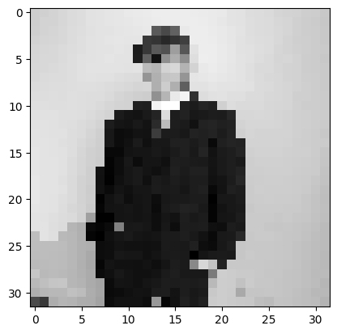

```python
%matplotlib inline
import os

image = "32x32AvaImg.png"
directory_path = os.path.abspath(os.getcwd())
#img_path = os.path.join(directory_path, 'test.JPG')
img_path = directory_path + "/" + image

import numpy as np
from PIL import Image
import matplotlib.pyplot as plt
import matplotlib as mpl

# Graph settings.
mpl.rcParams['image.cmap'] = 'gray'

# Load up the image, and normalise it
#########img_path = '../assets/a.png'
# Open image. We also convert to grayscale to make it simpler to deal with
img = np.asarray(Image.open(img_path).convert('L'))
# Normalise to 0-1
img = img / 255
img_size = img.shape

plt.imshow(img)
img
```

```
saved to .../assets/test.png
```

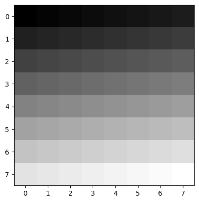

```python
#func to save images

# stackoverflow.com/questions/31544130/saving-an-imshow-like-image-while-preserving-resolution
def save_image(data, name, vmin=0, vmax=1):
    cmap = plt.cm.gray
    norm = plt.Normalize(vmin=vmin, vmax=vmax)

    img = cmap(norm(data))
    plt.imsave(name, img)
    print('saved to {}'.format(name))

# quick test
arr = np.linspace(-1, 1, 8 * 8).reshape((8, 8))
plt.imshow(arr)
save_image(arr, name=".../assets/test.png", vmin=-1, vmax=1)
```

[output not shown]

[output cut: 9 more lines]

[output not shown]

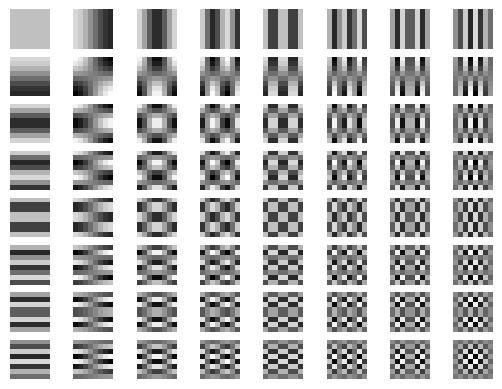

```python
import itertools
from scipy.fftpack import idct
freq_img = idct(idct(freq, axis=0), axis=1)

fig, axes = plt.subplots(8, 8)

for (x, y) in itertools.product(range(8), range(8)):
    freq = np.zeros((8, 8))
    freq[x, y] = 1
    freq_img = idct(idct(freq, axis=0, norm='ortho'), axis=1, norm='ortho')

    ax = axes[x, y]
    # Experimentally all things tend to be within this range
    ax.imshow(freq_img, vmin=-0.25, vmax=0.25)
    ax.axis('off')

    save_image(freq_img, name='../FourierTransform/assets/components-{}-{}.png'.format(x, y), vmin=-0.25, vmax=0.25)
```

```
array([[ 1.75903186e+01, -9.22709782e-01,  5.63388797e+00, ...,
        -1.53397897e-02,  1.31915945e-01, -7.81789210e-02],
       [ 3.93744258e+00,  9.57359127e-01, -2.37217047e+00, ...,
        -3.88795486e-02, -6.69849807e-02,  1.45413345e-01],
       [ 1.88211198e+00, -4.42874328e-01, -2.26674399e+00, ...,
         1.71948333e-01, -3.01965726e-02, -8.38018686e-02],
       ...,
       [-6.30165255e-02,  1.45024633e-02,  5.19339848e-02, ...,
         2.99821554e-02,  5.98237219e-03,  6.64804538e-02],
       [ 1.52011463e-01,  1.01343610e-02, -1.60720274e-01, ...,
         6.52352991e-02, -9.22375704e-03, -1.40101212e-01],
       [-2.13825867e-03,  4.60503712e-02,  3.16180347e-03, ...,
         2.21757904e-02, -1.18603703e-02, -6.46424388e-02]])
```

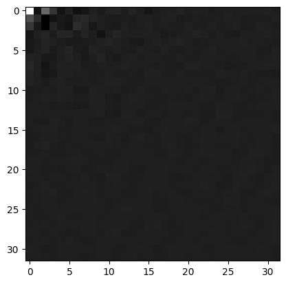

```python
from scipy.fftpack import dct

freqs = dct(dct(img, axis=0, norm='ortho'), axis=1, norm='ortho')
plt.imshow(freqs)
freqs
```

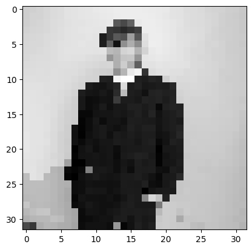

```python
freqs = dct(dct(img, axis=0, norm='ortho'), axis=1, norm='ortho')
reconstructed_img = idct(idct(freqs, axis=0, norm='ortho'), axis=1, norm='ortho')
plt.imshow(reconstructed_img)
```

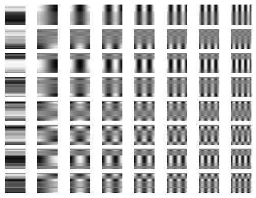

```python
# Lets draw the compnents that come out

# first need this function
def lerp(a, b, amt):
    '''Linear interpolate between a and b'''
    return a + (b - a) * amt

freqs = dct(dct(img, axis=0, norm='ortho'), axis=1, norm='ortho')

fig, axes = plt.subplots(8, 8)

for (x, y) in itertools.product(range(8), range(8)):
    freq_select = np.zeros((32, 32))
    freq_select[x, y] = 1

    new_freqs = np.dot(freqs, freq_select)

    freq_img = idct(idct(new_freqs, axis=0, norm='ortho'), axis=1, norm='ortho')

    # If we draw everything with in the same scale it's hard to see the smaller patterns
    # because they're so small and come out as mostly grey.
    # But if we draw them all with their own scale we can't see the relative size.
    # So we go somewhere between.
    scale_adjust_amt = 0.01
    vmin = lerp(freq_img.min(), -1, scale_adjust_amt)
    vmax = lerp(freq_img.max(), 1, scale_adjust_amt)

    ax = axes[x, y]
    ax.imshow(freq_img, vmin=vmin, vmax=vmax)
    ax.axis('off')
    #save_image(freq_img, name='../assets/img-components-{}-{}.png'.format(x, y), vmin=vmin, vmax=vmax)
```

```python
# Fill in a similar way to how jpegs do it?

def loop_like_a_jpeg(size):
    """Generates a bunch of tuples that loop over a matrix in a zig-zag way
    """
    flip_dir = False
    for i in range(size):
        r = range(i + 1)
        if flip_dir:
            r = reversed(r)

        for j in r:
            # Start at the right edge (0, i), and go upwards to the right
            yield (0 + j, i - j)
        flip_dir = not flip_dir

    for i in range(1, size):
        r = range(size - i)
        if flip_dir:
            r = reversed(r)

        for j in r:
            # Start the the bottom edge (i, size-1) and go upwards to the right
            yield(i + j, (size - 1) - j)
        flip_dir = not flip_dir

arr = np.zeros((4, 4))
for (i, (x, y)) in enumerate(loop_like_a_jpeg(4)):
#     print(x, y)
    arr[y, x] = i
arr
```

```
array([[ 0.,  1.,  5.,  6.],
       [ 2.,  4.,  7., 12.],
       [ 3.,  8., 11., 13.],
       [ 9., 10., 14., 15.]])
```

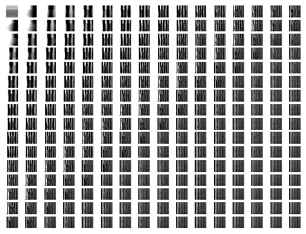

```python
freqs = dct(dct(img, axis=0, norm='ortho'), axis=1, norm='ortho')

fig, axes = plt.subplots(16, 16)

freq_select = np.zeros((32, 32))
for (y, x) in loop_like_a_jpeg(16):
    freq_select[x, y] = 1;

    new_freqs = np.dot(freqs, freq_select)

    freq_img = np.copy(idct(idct(new_freqs, axis=0, norm='ortho'), axis=1, norm='ortho'))

    ax = axes[x, y]
    ax.imshow(freq_img, vmin=0, vmax=1)
    ax.axis('off')
    #save_image(freq_img, name='../assets/img-buildup-{}-{}.png'.format(x, y), vmin=0, vmax=1)
```

[Cool Demo](https://isaacvr.github.io/coding/fourier_transform/)